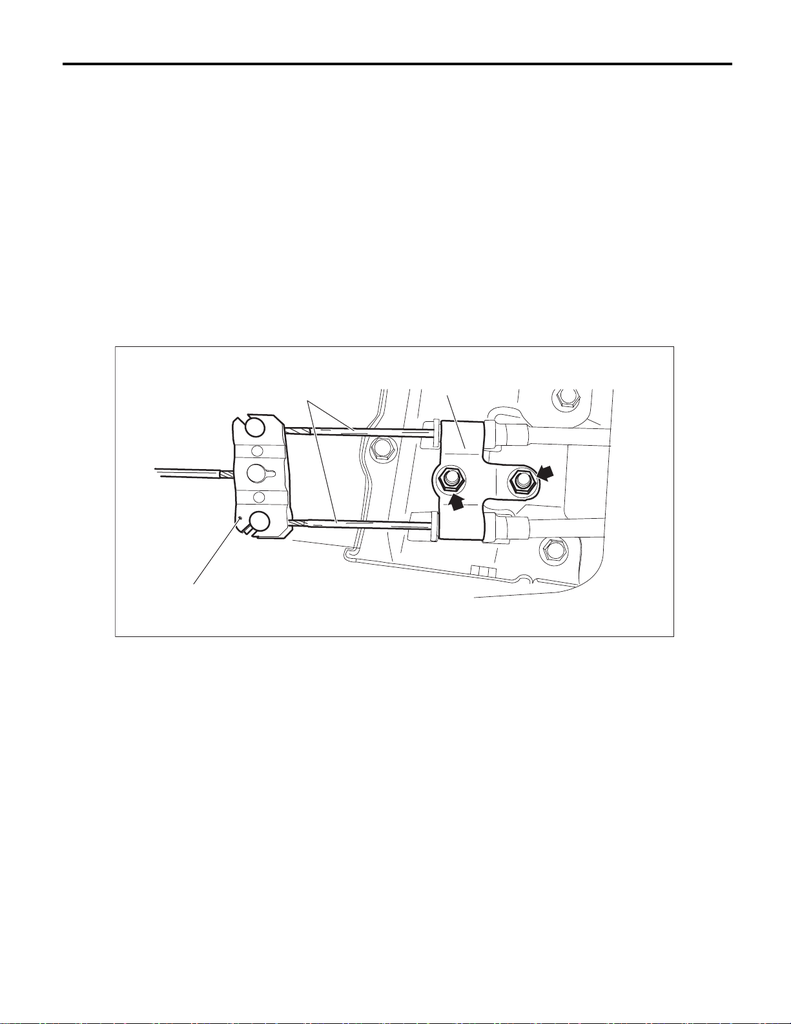

PB-8

Parking Brake Cable

PARKING BRAKE

3. Parking Brake Cable

A: REMOVAL

CAUTION:

Airbag system satellite safing sensor is located in the lower of the rear seat cushion center. Before

removing the rear seat, refer to “CAUTION” of “General Description” in “AIRBAG SYSTEM” section.

<Ref. to AB-9, CAUTION, General Description.>

1) Disconnect the ground cable from battery. <Ref. to NT-5, BATTERY, NOTE, Note.>

NOTE:

• For models other than STI model, disconnect the ground terminal from battery sensor.

• On CVT models, shift the select lever into “D” before disconnecting the battery ground cable.

• For the power seat, move the seat to the front-most position before removing the battery ground terminal.

2) Remove the console box assembly. <Ref. to EI-67, REMOVAL, Console Box.>

3) Remove the lever assembly - hand brake. <Ref. to PB-4, REMOVAL, Parking Brake Lever.>

4) Remove the nut and remove the clamp A - hand brake cable (a).

5) Remove the inner cable end (c) from the equalizer (b).

6) Remove the rear seat cushion assembly. <Ref. to SE-29, REMOVAL, Rear Seat.>

PB-00245

(b)

(c)

(a)

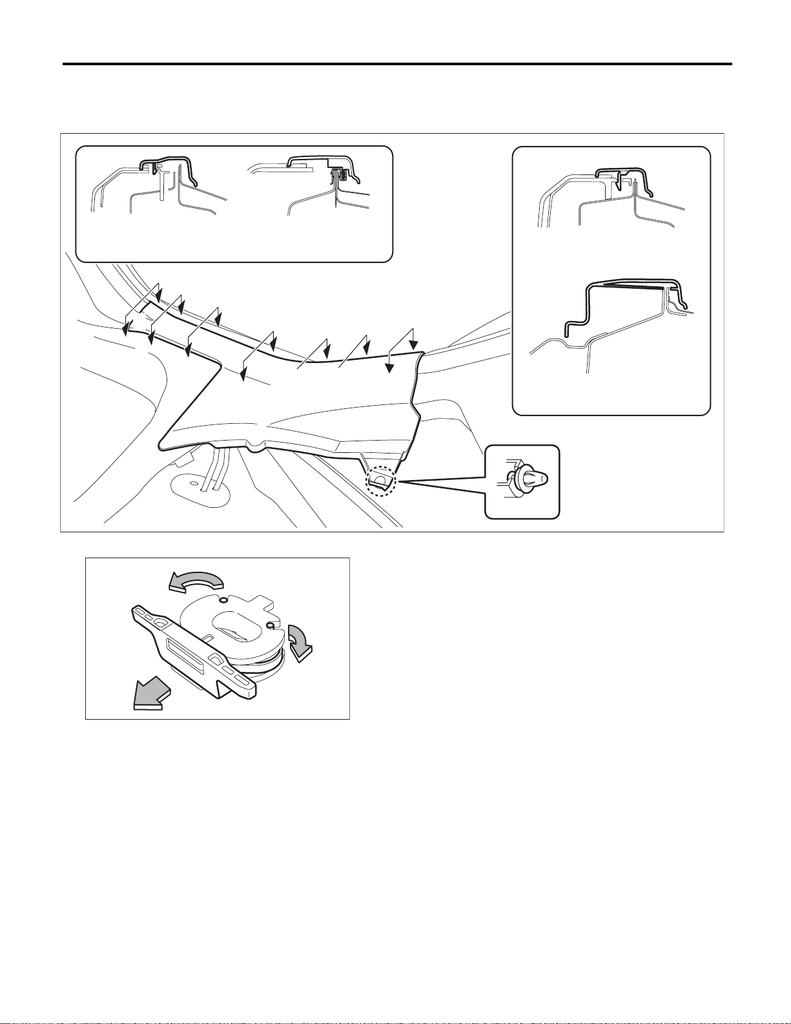

PB-9

Parking Brake Cable

PARKING BRAKE

7) Release the clips and claws, and remove the side sill covers - rear INN on the left and right sides.

CAUTION:

Do not pull with excessive force. Doing so may damage the claws of the side sill cover - rear INN.

8) Remove the clips and knobs of the hook - seat cushion rear.

EI-03497

A

A

B

B

C-C

D-D

D

D

C

C

C

C

B

B

A-A

B-B

EI-03524

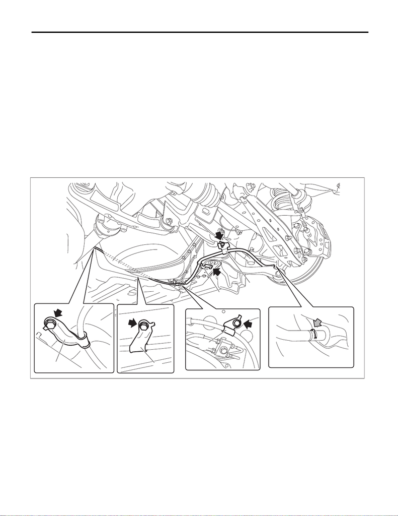

PB-10

Parking Brake Cable

PARKING BRAKE

9) Turn over the floor carpet and remove the grommet of the cable assembly - parking brake from the rear

floor.

10) Lift up the vehicle, and then remove the rear wheels.

11) Remove the fuel tank protector.

• Except for STI model <Ref. to FU(w/o STI)-151, REMOVAL, Fuel Tank Protector.>

• STI model <Ref. to FU(STI)-66, REMOVAL, Fuel Tank Protector.>

12) Remove the exhaust pipe and muffler.

• Center exhaust pipe & rear exhaust pipe: <Ref. to EX(STI)-12, REMOVAL, Rear Exhaust Pipe.>

• Muffler: <Ref. to EX(STI)-14, REMOVAL, Muffler.>

13) Remove the propeller shaft assembly. <Ref. to DS-12, REMOVAL, Propeller Shaft.>

14) Remove the cable assembly - parking brake from the lever section of parking brake shoe. <Ref. to PB-

12, REMOVAL, Parking Brake Assembly (Rear Disc Brake).>

15) Remove the cable assembly - parking brake.

(1) Remove the clamp B - hand brake cable (a) from the back plate - rear brake.

(2) Remove the cable clamp (b) from the lateral link assembly - front.

(3) Remove the cable clamp (c) from the sub frame support.

(4) Remove the cable clamp (d) from the rear floor.

PB-00343

(a)

(b)

(c)

(d)

(c)

(c)

[figure not shown]

PB-11

Parking Brake Cable

PARKING BRAKE

B: INSTALLATION

CAUTION:

• After installing the backrest assembly, make sure that each seat belt operates normally.

• Make sure that they are properly secured on each hook on the vehicle side.

1) Install the cable assembly - parking brake.

Tightening torque:

Cable clamp: 18 N·m (1.8 kgf-m, 13.3 ft-lb)

2) Install the cable assembly - parking brake to the lever section of parking brake shoe. <Ref. to PB-14, IN-

STALLATION, Parking Brake Assembly (Rear Disc Brake).>

3) Install the grommet to the rear floor.

4) Install the propeller shaft assembly. <Ref. to DS-14, INSTALLATION, Propeller Shaft.>

5) Install the exhaust pipe and muffler.

• Center exhaust pipe & rear exhaust pipe: <Ref. to EX(STI)-12, INSTALLATION, Rear Exhaust Pipe.>

• Muffler: <Ref. to EX(STI)-15, INSTALLATION, Muffler.>

6) Install the fuel tank protector.

• Except for STI model <Ref. to FU(w/o STI)-151, INSTALLATION, Fuel Tank Protector.>

• STI model <Ref. to FU(STI)-66, INSTALLATION, Fuel Tank Protector.>

7) Place the floor mat to the original position, and then attach the clip and the knob of the hook - seat cushion

rear.

8) Install the side sill covers - rear INN on the right and left side.

9) Install the rear seat cushion assembly.

10) Install the inner cable end to equalizer, and install the clamp A - hand brake cable.

11) Install the lever assembly - hand brake.

Tightening torque:

18 N·m (1.8 kgf-m, 13.3 ft-lb)

12) Install the console box assembly.

13) Install the rear wheels.

Tightening torque:

120 N·m (12.2 kgf-m, 88.5 ft-lb)

14) Connect the battery ground terminal. <Ref. to NT-5, BATTERY, NOTE, Note.>

NOTE:

For models other than STI model, connect the ground terminal to battery sensor.

C: INSPECTION

Check the removed cable and replace if damaged, rusty or malfunctioning.

1) Check the cable for smooth operation.

2) Check the inner cable for damage and rust.

3) Check the outer cable for damage, bends and cracks.